# Ad Frequency and Product Types

## What’s going on with this data?

This report visualizes the frequency and ad views across various product types. The data were collected through observational logging, focusing on the types of products being advertised and how frequently they were seen.

## Product Types Frequency

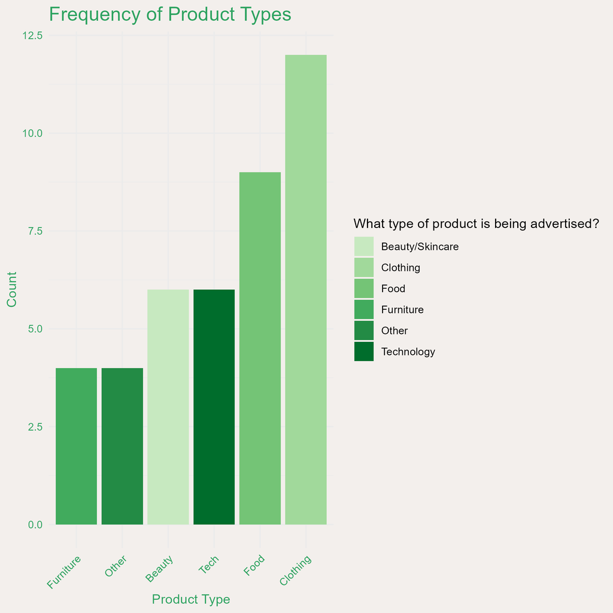

**Bar plot of Product Types**

## Ad Frequency by Product Type

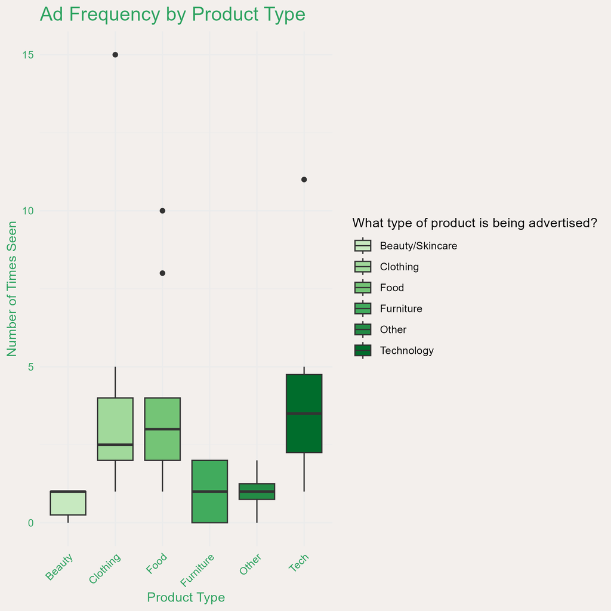

**Box plot of Ad Frequency**

This box plot shows the distribution of how many times each product ad was seen. It gives us insight into the variance in ad frequency for different product categories.

## Average Ad Views Over Time

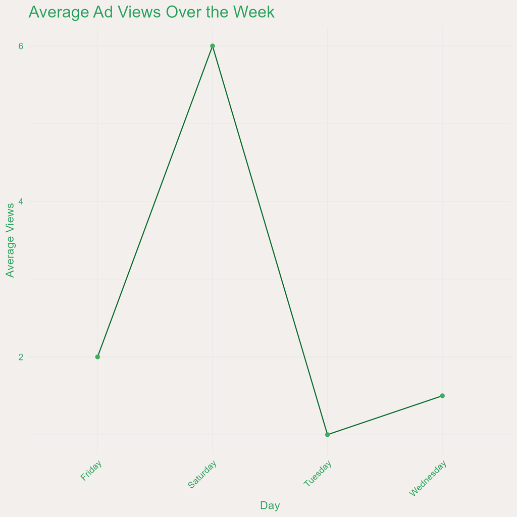

**Line plot of Ad Views**

The line plot above displays the average views per day of the week. It helps to understand how ad frequency varies throughout the week, with some days likely seeing more ads due to market trends or campaign strategies.

## Conclusion

From the visualizations, we gain insights into ad frequency, product type popularity, and temporal trends. The data and these plots help inform future ad strategies, focusing on the most impactful product categories and times for optimal engagement.